# Explainer on String Detect

Elena Santa Cruz

May 3, 2022

## Pattern Matching with String Detect

Pattern matching using string detect helps when there items within a column that cannot be strictly filtered for.

When using string detect, think about pulling specific information you want from out of a column. Think of it like a magnet trying to attract all the rows of data that you are looking for - of which you listed out in your code.

Say there was a qualitative data set that was about favorite breakfast foods. We want to pull out all the rows that mention “waffles” to get that quantitative number. The magnet is the code using the string detect that is attracting all the waffle statements. This graphic depicts this example.

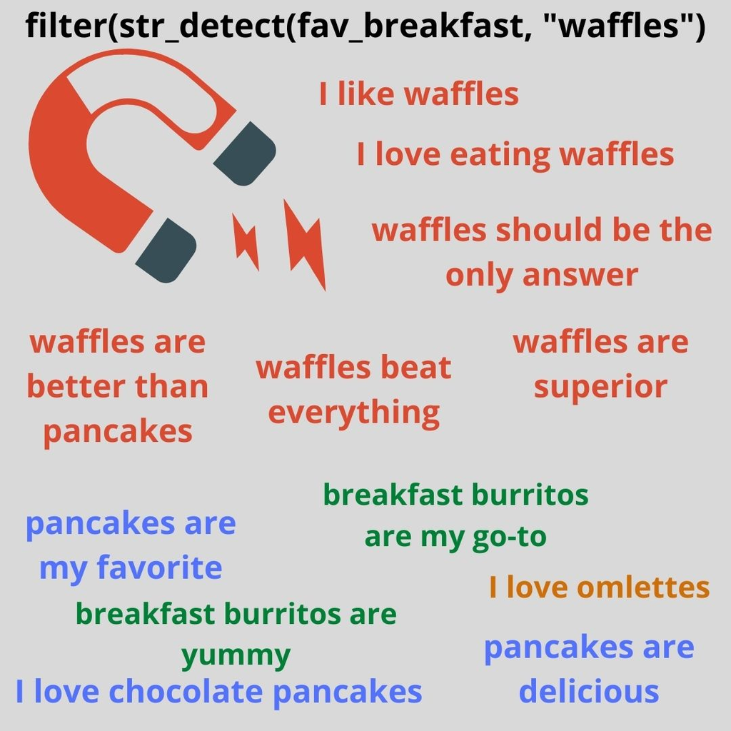

In order to use string detect, the stringr package in the initial chunk that loads all libraries must be loaded and run.

Per the class textbook, the base formula for using string detect is:

```
filter(str_detect(a_column_name, "the regular expression you are searching for")
```

You can use the expression you are seeking on its own, or you can widen or narrow your search using some rules. Examples include:

- Using “^” at the beginning of the pattern you are searching for, which is saying that you are looking for instances where the pattern is listed at the beginning of the data value within the column.
- Using “$” at the beginning of the pattern you searching for, which is saying that you are looking for instances where the pattern is listed at the end of the data value within the column.
- Using “|” between the patterns you are searching for, stating that you want all rows of data that mention either of those items.

## Pattern Matching with Armed Conflict Location and Event Data

I’ll be using data from the Armed Conflict Location and Event Data Project (ACLED) to put this in a real-world context.

Here is a United States data set pulled from the ACLED’s website from May 25, 2020 to July 31, 2020. A lot of events were happening during this time, namely protests in response to the murder of George Floyd, counter-protests, and protests against coronavirus mandates.

Here is the data set (which came from https://acleddata.com/data-export-tool/):

```r
acled_2020 <- read_csv("acled_2020.csv")
```

The ACLED tracks sociopolitical events around the world through news reports. It has a lot of specific columns, but there is a “notes” column that gives a brief description of the event. Therefore, we can’t just use the filter function alone to get an entire row’s worth of data or details within multiple events.

The ACLED codes additional items within the notes column - it might narrow down the event type, whether there was an armed presence at an event, or if there was a counter demonstration at a protest. Sometimes these “tags” will be listed at the beginning of the note.

Let’s look at events with an armed presence. An armed presence means that there were people at a demonstration who were not part of the actual event, but are there to provide “community protection” or intimidate the demonstrators.

This is how we look for those using a string detect:

```r
acled_2020 %>%
  filter(str_detect(notes, "armed presence"))%>%
  select(notes) %>%
  head(5)
```

| notes |
| --- |
| On 26 July 2020, approximately 250 people marched to the county jail in Eugene (Oregon) as a response to the deployment of tear gas during a demonstration the previous night and in support of the Blac… |
| On 24 July 2020, about 35 people protested in Mifflintown (Pennsylvania) for Black Lives Matter. Another 20 counter-demonstrators protested around the courthouse as well. Armed members of the Light Fo… |
| On 22 July 2020, about 50 people staged a march in Wyomissing (Pennsylvania) in support of the Black Lives Matter movement and against the treatment and arrest of a local Black man, who was tasered by… |
| On 19 July 2020, people staged a protest in Fishers (Indiana) in support of the Black Lives Matter movement and against police brutality and the killing of George Floyd. At least one man followed prot… |
| On 12 July 2020, multiple groups protested in Charleston (South Carolina) for and against confederate monuments and flags. Armed members of the Light Foot Militia was present, but did not engage in th… |

There are multiple “event types” within this data. There are protests, riots, strategic developments, etc.

Within those event types, there are sub-event types that are listed to further specify the type of event that took place. Protests have sub-event types that categorize whether it was a peaceful protest or a protest that had an intervention.

The “Strategic Development” event type with the sub-event “other” typically has information listed in the notes column to specify what that “other” might mean. If there are strategic developments with the “Other” sub-event type, the notes section begins by stating what kind of activity the event was, like if it was a “Non-violent activity”.

According to the ACLED’s United States code book, strategic developments with “Other” as their sub-type are:

- “Non-violent activity” where there was an armed group present, but did not engage with or be part of the demonstration.
- “Non-violent activity” where there were armed groups present whose goal was to provide “community protection”, or simply patrolled the area in case other demonstrations arose.

Let’s look for those by using code. First let’s filter for all strategic developments with the sub-event type listed as “Other” to see what we are working with.

```r
acled_2020 %>%
  filter(event_type == "Strategic developments") %>%
  filter(sub_event_type == "Other") %>%
  select("notes") %>%
  head(5)
```

| notes |
| --- |
| Other: On 31 July 2020, after a Black Lives Matter protest in Albuquerque (New Mexico), members of the New Mexico Civil Guard had a verbal dispute with protesters at a sandwich shop. There was a repor… |
| Other: On 28 July 2020, a white woman accelerated her car towards three Black moms and their children in Swampscott (Massachusetts), stopping just short of hitting them. She then shouted racial insult… |
| Non-violent activity: On 26 July 2020, a man labelled as press reportedly drew his handgun at protesters affiliated with Black Unity in Eugene (Oregon) before demonstrators chased him away. |
| Training: On 25 July 2020, the Kansas 34th Light Foot Militia held a field training in Pretty Prairie (Kansas), including weapon safety training and a discussion on militia history. |
| Non-violent activity: Around 25 July 2020 (as reported), a group of armed vigilantes began patrolling areas of Minneapolis (Minnesota) in response to some looting and vandalism in the wake of unrest s… |

So there are additional labels that these types of events/sub-events have that differ from “Non-violent activity”. Let’s use the string detect to filter for just those. Here is where we will use our “^” rule to indicate that we are looking for rows that begin with the phrase we are looking for.

```r
acled_2020 %>%
  filter(event_type == "Strategic developments") %>%
  filter(sub_event_type == "Other") %>%
  filter(str_detect(notes, "^Non-violent activity")) %>%
  select("notes") %>%
  head(5)
```

| notes |
| --- |
| Non-violent activity: On 26 July 2020, a man labelled as press reportedly drew his handgun at protesters affiliated with Black Unity in Eugene (Oregon) before demonstrators chased him away. |
| Non-violent activity: Around 25 July 2020 (as reported), a group of armed vigilantes began patrolling areas of Minneapolis (Minnesota) in response to some looting and vandalism in the wake of unrest s… |
| Non-violent activity: On 24 July 2020, the Light Foot Militia patrolled a BLM protest in Mifflintown (Pennsylvania) to prevent violence between demonstrators and counter-demonstrators. |
| Non-violent activity: On 22 July 2020, armed members of Pennsylvania Volunteer Militia watched over a protest held by about 50 people in Wyomissing (Pennsylvania) associated with the Black Lives Matte… |
| Non-violent activity: On 19 July 2020, at least one man armed with an assault rifle and body armor followed people as they staged a protest in Fishers (Indiana) in support of the Black Lives Matter mo… |

Lastly, let’s try to use the “or” rule, depicted as “|” to show events that either had an armed presence and events that had counter-demonstrators, where two groups are protesting at the same time who are ideologically against each other:

```r
acled_2020 %>%
  filter(str_detect(notes, "armed presence|counter-demonstration")) %>%
  select(notes)
```

| notes |
| --- |
| On 31 July 2020, about 200 people gathered in a park in Ferndale (Washington) to demonstrate in favor of Black Lives Matter and against police brutality. A small group of counter-demonstrators also ga… |
| On 31 July 2020, more than 100 people protested at the Lauderdale County Courthouse in Florence (Alabama) for a Unite Against the Klan protest organised by Project Say Something, calling for the reloc… |
| On 31 July 2020, an unknown number of people joined a march organised by Black Collective Movement, Loud for Justice, and Black N' Tampa, to the home of the Mayor in Tampa (Florida) in support of the … |
| On 31 July 2020, nearly 400 people staged a demonstration in Bozeman (Montana) in support of the police and President Trump. The demonstration was organized by the Republican Party. A small group of B… |
| On 31 July 2020, students protested in Chelsea (Michigan) in support of the Black Lives Matter movement and against police brutality and the death of George Floyd. Counter protesters staged a 'Parade … |
| On 31 July 2020, about 40 Blue Lives Matter protesters demonstrated in Arlington Heights (Illinois) in support of the police and the Blue Lives Matter movement. A few counter protesters demonstrated i… |
| On 31 July 2020, a large number of Antifa supporters demonstrated in the Sunland-Tujunga neighborhood of Los Angeles - San Fernando Valley (California) in support of the Black Lives Matter movement an… |
| On 30 July 2020, people led by the Knights of Columbus protested in Wilmington (North Carolina) in support of law enforcement. Counter-demonstrators marched for Black Lives Matter. The two groups argu… |
| On 30 July 2020, people staged a counter protest in Saratoga Springs (New York) in support of Black Lives Matter movements and against police brutality in the wake of the death of George Floyd in resp… |
| On 30 July 2020, about 20 anti-Trump demonstrators staged a march in Wilkes-Barre (Pennsylvania) and an activist burned 3 flags while delivering a speech on Trump. There was a counter-protest held wit… |

[output cut: 549 more lines]

## Conclusion

Pattern matching using a string detect is a good tool to use when you can’t filter for what you want in a normal context.

This is especially true if looking at data sets with full addresses in them and you are looking for a zip code (because you don’t know if a street was spelled correctly) or different versions of a street name, because, well it could have been spelled incorrectly! This just touched the basics of it.